# Assignment: Temporal Diversity

## 4) TIME SERIES ANALYSIS

In the R code chunk below, do the following:

1. Create a time-by-species matrix that includes year, month, and plot_id for a site other than plot_id 2.
2. Examine per-hectare rodent abundance using simple moving average smoothing.
3. Test whether your data meets the assumption of stationarity.
4. If it does not meet this asumption, explore wasy to make your data stationary.
5. Examine and plot time lags using the partial autocorrelation function (PACF) and autocorrelation function (ACR).
6. Use the tools outlined in the Handout to create an ARMA model.

```r
time.by.species_2 <- filter(portal, taxa=="Rodent") %>% group_by(year,month,plot_id) %>% count(taxon)

time.by.species_2$season <- NA
time.by.species_2$season <- time.by.species_2$month %in% c(6:10)

time.by.species_2$season <- ifelse(time.by.species_2$season == T, "rain", "norain")
group_by(time.by.species_2, year, season)
```

```
## Source: local data frame [16,391 x 6]
## Groups: year, season [52]
##
##     year month plot_id                    taxon     n season
##    <int> <int>   <int>                    <chr> <int>  <chr>
## 1   1977     7       1       Dipodomys_merriami     2   rain
## 2   1977     7       1       Perognathus_flavus     1   rain
## 3   1977     7       2 Chaetodipus_penicillatus     1   rain
## 4   1977     7       2       Dipodomys_merriami     1   rain
## 5   1977     7       2         Neotoma_albigula     1   rain
## 6   1977     7       2      Peromyscus_eremicus     1   rain
## 7   1977     7       3       Dipodomys_merriami     2   rain
## 8   1977     7       3    Dipodomys_spectabilis     1   rain
## 9   1977     7       3         Neotoma_albigula     1   rain
## 10  1977     7       4       Dipodomys_merriami     1   rain
## # ... with 16,381 more rows
```

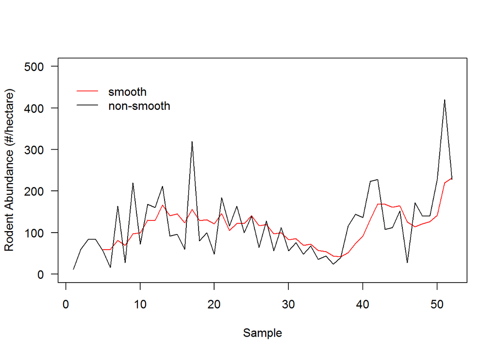

```r
#CHANGE TO 6!!!!!!!!!!!!!!!!!!!!!!!!!!!!!!!!!!!!!!!!!!!!!!!!!!!!
abund <- filter(time.by.species_2, plot_id == 6) %>%
  group_by(year, season) %>%
  count(wt = n)

abund$nn <- abund$nn*4

abund.ts <- ts(abund$nn, frequency = 2, start = c(1977, 2))

#plot.ts(abund.ts, type = "l", ylab = "Rodent Abundance (#/hectare",
#        xlab = "Time (year)", las = 1, ylim = c(0,500))

abund.sm <- SMA(abund$nn, n = 5)
plot(abund.sm, type = "l", col = "red", ylab = "Rodent Abundance (#/hectare)",
     xlab = "Sample", las = 1, ylim = c(0, 500))
lines(abund$nn, col = "black")

legend(0, 475, col = c("red", "black"), lty = c(1,1),
       c("smooth", "non-smooth"), bty= "n", cex = 1)
```

```r
#TESTING STATIONARITY###############################################################################
adf.raw <- adf.test(abund.ts, alternative = "stationary")
adf.raw$p.value
```

```
## [1] 0.8389527
```

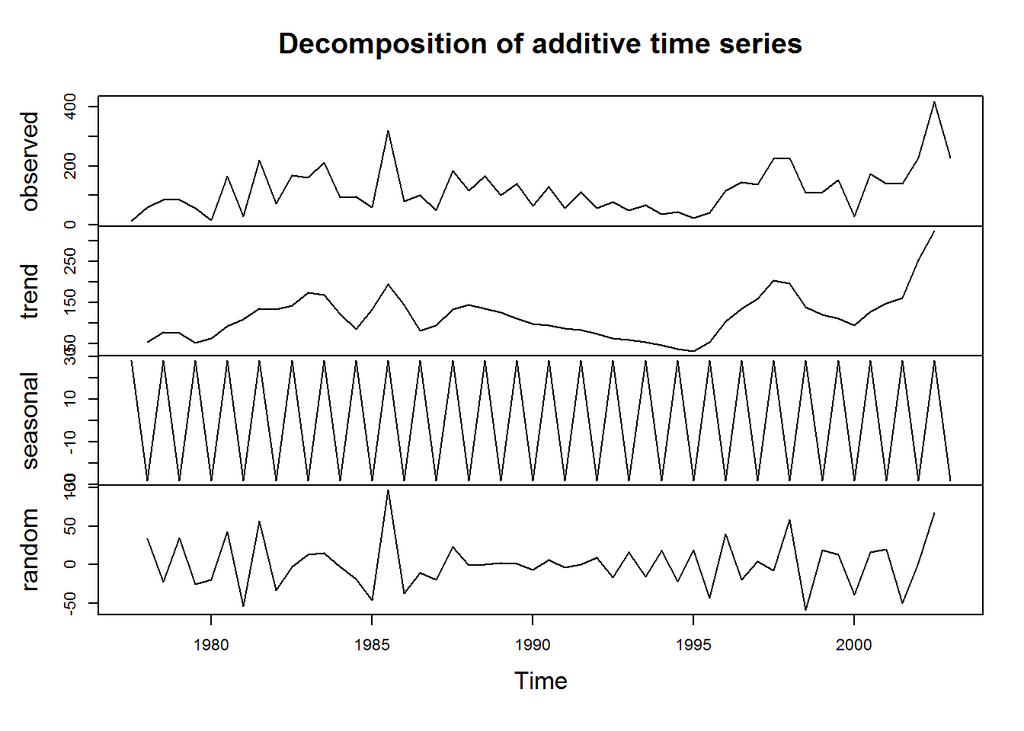

```r
abund.comp <- decompose(abund.ts)
plot(abund.comp)
```

```r
#Differencing
abund.ts.diff <- diff(abund.ts)
adf.diff <- adf.test(abund.ts.diff, alternative = "stationary")
adf.diff$p.value
```

```
## [1] 0.02504877
```

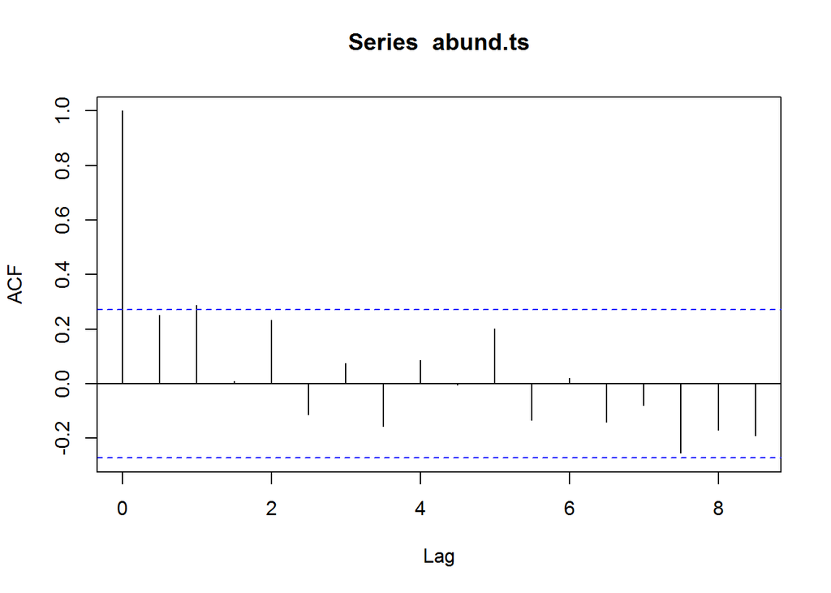

```r
acf(abund.ts)
```

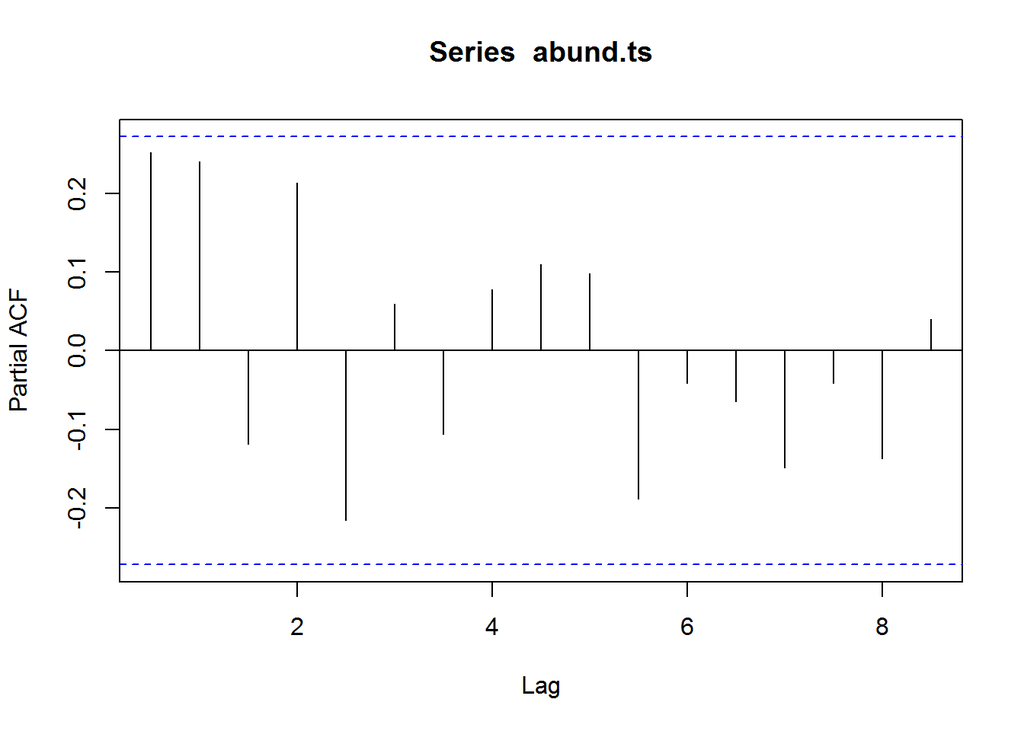

```r
pacf(abund.ts)
```

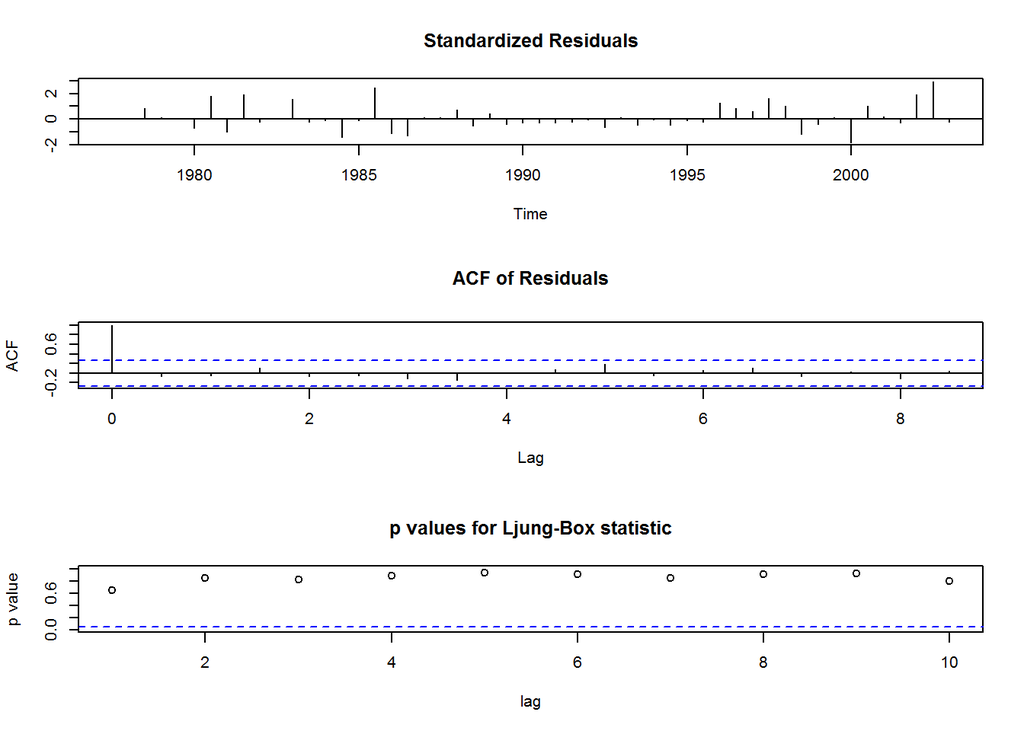

```r
abund.arm <- auto.arima(abund.ts)
abund.arm <- arima((abund.ts), c(0,0,1), seasonal = list(order = c(2, 1, 0), period = 2), include.mean = T)
tsdiag(abund.arm)
```

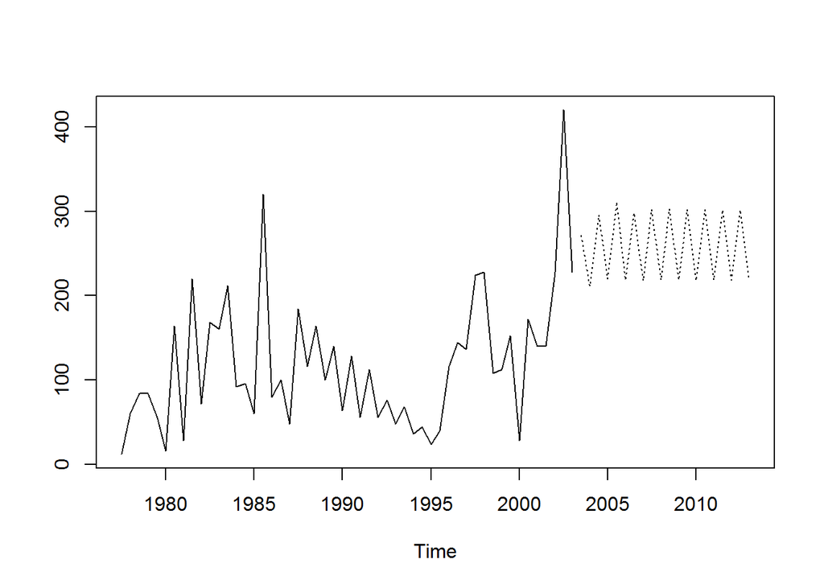

```r
pred.arm <- predict(abund.arm, n.ahead = 20)
ts.plot(abund.ts, pred.arm$pred, lty= c(1,3))
```

*Question 3*: Describe the results from your time series analysis.

1. Does your data meet the assumption of stationarity? If not, what does this violation imply?
2. What does the ACF function do and how does it relate to the ARMA model? How does this differ from the autocorrelation function (ACF)?
3. What results can you conclude from your full ARMA model along with other methods outlined in the time series setcion of the Handout?

## 5) REPEATED MEASURES ANALYSIS OF VARIANCE (RM-ANOVA)

In the R code chunk below, do the following:

1. Create an appropriate data frame for RM-ANOVA (e.g., yearly species abundance values within plots).
2. Calculate the inverse of Simpson’s diversity for each year, and plot it as a function of year for the Control and Rodent Exclosure plots.
3. Perform an RM-ANOVA and construct a F-test using the AR(1), compound symmetery, and unstructured covariance structures.

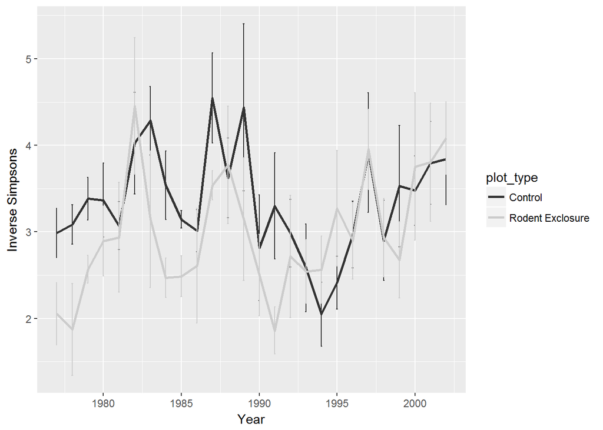

```r
time.by.species <- group_by(portal, year, plot_id,
                            plot_type) %>% count(taxon) %>% spread(key = taxon, value = n, fill = 0)

inv_s <- diversity(as.data.frame(time.by.species)[,-c(1:3)], "inv")


rich.all <- data.frame(time.by.species[,1:3,], inv_s)
names(rich.all)[4] <- "inverse_S"

rich.treat <- rich.all[which(rich.all$plot_type == "Control" | rich.all$plot_type == "Rodent Exclosure"), ]



rich.treat.plot <- group_by(rich.treat, plot_type, year) %>%
  summarise(
    mean = mean(inverse_S),
    sd = sd(inverse_S),
    n = n(),
    sem = sd/sqrt(n))

rich.plot <- ggplot(rich.treat.plot, aes(x = year, y = mean, color = plot_type)) +
  geom_line(size = 1, show.legend = T) +
  geom_errorbar(aes(ymin = mean - sem, ymax = mean + sem), width = .1) +
  xlim(1977, 2002)+
  xlab("Year")+
  ylab("Inverse Simpsons")+
  scale_color_grey()
plot(rich.plot)
```

```r
#Autoregressive process order 1
rich.rm <- lme(inverse_S ~ plot_type * year, random=  ~ 1 | plot_id,
               correlation = corAR1(form = ~1 | plot_id),
               data=rich.treat)

summary(rich.rm)
```

```
## Linear mixed-effects model fit by REML
##  Data: rich.treat
##        AIC      BIC    logLik
##   1153.217 1180.322 -569.6087
##
## Random effects:
##  Formula: ~1 | plot_id
##         (Intercept) Residual
## StdDev:   0.6469478 1.250206
##
## Correlation Structure: AR(1)
##  Formula: ~1 | plot_id
##  Parameter estimate(s):
##       Phi
## 0.4250398
## Fixed effects: inverse_S ~ plot_type * year
##                                    Value Std.Error  DF    t-value p-value
## (Intercept)                      1.36695  33.32814 343  0.0410150  0.9673
## plot_typeRodent Exclosure      -73.37575  52.01883  12 -1.4105613  0.1838
## year                             0.00100   0.01675 343  0.0595739  0.9525
## plot_typeRodent Exclosure:year   0.03670   0.02614 343  1.4039132  0.1612
##  Correlation:
##                                (Intr) plt_RE year
## plot_typeRodent Exclosure      -0.641
## year                           -1.000  0.641
## plot_typeRodent Exclosure:year  0.641 -1.000 -0.641
##
## Standardized Within-Group Residuals:
##         Min          Q1         Med          Q3         Max
## -1.93162654 -0.70434296 -0.08293334  0.45856267  5.06139168
##
## Number of Observations: 359
## Number of Groups: 14
```

```r
anova(rich.rm)
```

```
##                numDF denDF   F-value p-value
## (Intercept)        1   343 256.22009  <.0001
## plot_type          1    12   0.72274  0.4119
## year               1   343   1.56060  0.2124
## plot_type:year     1   343   1.97097  0.1612
```

```r
set.caption("RMANOVA for Portal")
pander(anova(rich.rm))
```

RMANOVA for Portal

|  | numDF | denDF | F-value | p-value |
| --- | --- | --- | --- | --- |
| **(Intercept)** | 1 | 343 | 256.2 | 0 |
| **plot_type** | 1 | 12 | 0.7227 | 0.4119 |
| **year** | 1 | 343 | 1.561 | 0.2124 |
| **plot_type:year** | 1 | 343 | 1.971 | 0.1612 |

```r
lsmeans(rich.rm, ~plot_type)
```

```
## NOTE: Results may be misleading due to involvement in interactions
```

```
##  plot_type          lsmean        SE df lower.CL upper.CL
##  Control          3.352478 0.2644674 13 2.781131 3.923825
##  Rodent Exclosure 3.002943 0.3066216 12 2.334872 3.671014
##
## Confidence level used: 0.95
```

```r
#Compounds symmetry
rich.rm <- lme(inverse_S ~ plot_type * year, random=  ~ 1 | plot_id,
               correlation = corCompSymm(form = ~1 | plot_id),
               data=rich.treat)

summary(rich.rm)
```

```
## Linear mixed-effects model fit by REML
##  Data: rich.treat
##        AIC      BIC    logLik
##   1215.368 1242.473 -600.6842
##
## Random effects:
##  Formula: ~1 | plot_id
##         (Intercept) Residual
## StdDev:   0.7104222 1.214275
##
## Correlation Structure: Compound symmetry
##  Formula: ~1 | plot_id
##  Parameter estimate(s):
##          Rho
## 6.672013e-18
## Fixed effects: inverse_S ~ plot_type * year
##                                    Value Std.Error  DF    t-value p-value
## (Intercept)                     13.26069  22.33564 343  0.5937008  0.5531
## plot_typeRodent Exclosure      -68.60423  34.97126  12 -1.9617316  0.0734
## year                            -0.00498   0.01123 343 -0.4438008  0.6575
## plot_typeRodent Exclosure:year   0.03431   0.01758 343  1.9518712  0.0518
##  Correlation:
##                                (Intr) plt_RE year
## plot_typeRodent Exclosure      -0.639
## year                           -1.000  0.639
## plot_typeRodent Exclosure:year  0.639 -1.000 -0.639
##
## Standardized Within-Group Residuals:
##        Min         Q1        Med         Q3        Max
## -2.0346517 -0.6823806 -0.1001395  0.4790022  5.1406695
##
## Number of Observations: 359
## Number of Groups: 14
```

```r
anova(rich.rm)
```

```
##                numDF denDF   F-value p-value
## (Intercept)        1   343 255.02615  <.0001
## plot_type          1    12   0.73483  0.4081
## year               1   343   1.08893  0.2974
## plot_type:year     1   343   3.80980  0.0518
```

```r
set.caption("RMANOVA for Portal")
pander(anova(rich.rm))
```

RMANOVA for Portal

|  | numDF | denDF | F-value | p-value |
| --- | --- | --- | --- | --- |
| **(Intercept)** | 1 | 343 | 255 | 0 |
| **plot_type** | 1 | 12 | 0.7348 | 0.4081 |
| **year** | 1 | 343 | 1.089 | 0.2974 |
| **plot_type:year** | 1 | 343 | 3.81 | 0.05177 |

```r
lsmeans(rich.rm, ~plot_type)
```

```
## NOTE: Results may be misleading due to involvement in interactions
```

```
##  plot_type          lsmean        SE df lower.CL upper.CL
##  Control          3.348317 0.2649103 13 2.776013 3.920621
##  Rodent Exclosure 2.997377 0.3064250 12 2.329735 3.665020
##
## Confidence level used: 0.95
```

```r
#Unstructured
rich.rm <- lme(inverse_S ~ plot_type * year, random=  ~ 1 | plot_id,
               data=rich.treat)

summary(rich.rm)
```

```
## Linear mixed-effects model fit by REML
##  Data: rich.treat
##        AIC      BIC    logLik
##   1213.368 1236.601 -600.6842
##
## Random effects:
##  Formula: ~1 | plot_id
##         (Intercept) Residual
## StdDev:   0.7104222 1.214275
##
## Fixed effects: inverse_S ~ plot_type * year
##                                    Value Std.Error  DF    t-value p-value
## (Intercept)                     13.26069  22.33564 343  0.5937008  0.5531
## plot_typeRodent Exclosure      -68.60423  34.97126  12 -1.9617316  0.0734
## year                            -0.00498   0.01123 343 -0.4438008  0.6575
## plot_typeRodent Exclosure:year   0.03431   0.01758 343  1.9518712  0.0518
##  Correlation:
##                                (Intr) plt_RE year
## plot_typeRodent Exclosure      -0.639
## year                           -1.000  0.639
## plot_typeRodent Exclosure:year  0.639 -1.000 -0.639
##
## Standardized Within-Group Residuals:
##        Min         Q1        Med         Q3        Max
## -2.0346517 -0.6823806 -0.1001395  0.4790022  5.1406695
##
## Number of Observations: 359
## Number of Groups: 14
```

```r
anova(rich.rm)
```

```
##                numDF denDF   F-value p-value
## (Intercept)        1   343 255.02615  <.0001
## plot_type          1    12   0.73483  0.4081
## year               1   343   1.08893  0.2974
## plot_type:year     1   343   3.80980  0.0518
```

```r
set.caption("RMANOVA for Portal")
pander(anova(rich.rm))
```

RMANOVA for Portal

|  | numDF | denDF | F-value | p-value |
| --- | --- | --- | --- | --- |
| **(Intercept)** | 1 | 343 | 255 | 0 |
| **plot_type** | 1 | 12 | 0.7348 | 0.4081 |
| **year** | 1 | 343 | 1.089 | 0.2974 |
| **plot_type:year** | 1 | 343 | 3.81 | 0.05177 |

```r
lsmeans(rich.rm, ~plot_type)
```

```
## NOTE: Results may be misleading due to involvement in interactions
```

```
##  plot_type          lsmean        SE df lower.CL upper.CL
##  Control          3.348317 0.2649103 13 2.776013 3.920621
##  Rodent Exclosure 2.997377 0.3064250 12 2.329735 3.665020
##
## Confidence level used: 0.95
```

*Question 4*: Describe the results from your RM-ANOVA.

1. In your own words describe what a RM-ANOVA test is doing
2. Is there a noticeable trend in the inverse of Simpson’s diversity over time?
3. What does the result of your F-test tell you?
4. Of the three RM-ANOVA models with different covariance structures, which one is best? How does this affect the interpretation of your data?

## 6) TEMPORAL BETA DIVERSITY

### Turnover

In the R code chunk below, do the following:

1. Calculate species abundances for each taxonomic group (the `taxa` column).
2. Calculate total turnover and turnover due to the gain/loss of species for each group.
3. Visualize turnover within each group

```r
portal.species.abunds <- group_by(portal, year, taxa) %>% count(taxon)

portal.total <- turnover(df = portal.species.abunds,
                         time.var = "year",
                         species.var = "taxon",
                         abundance.var = "n",
                         replicate.var = "taxa",
                         metric = "total")

portal.appearance <- turnover(df = portal.species.abunds,
                         time.var = "year",
                         species.var = "taxon",
                         abundance.var = "n",
                         replicate.var = "taxa",
                         metric = "appearance")

portal.disappearance <- turnover(df = portal.species.abunds,
                         time.var = "year",
                         species.var = "taxon",
                         abundance.var = "n",
                         replicate.var = "taxa",
                         metric = "disappearance")

portal.turnover <- full_join(portal.total, portal.disappearance) %>%
  full_join(portal.appearance)
```

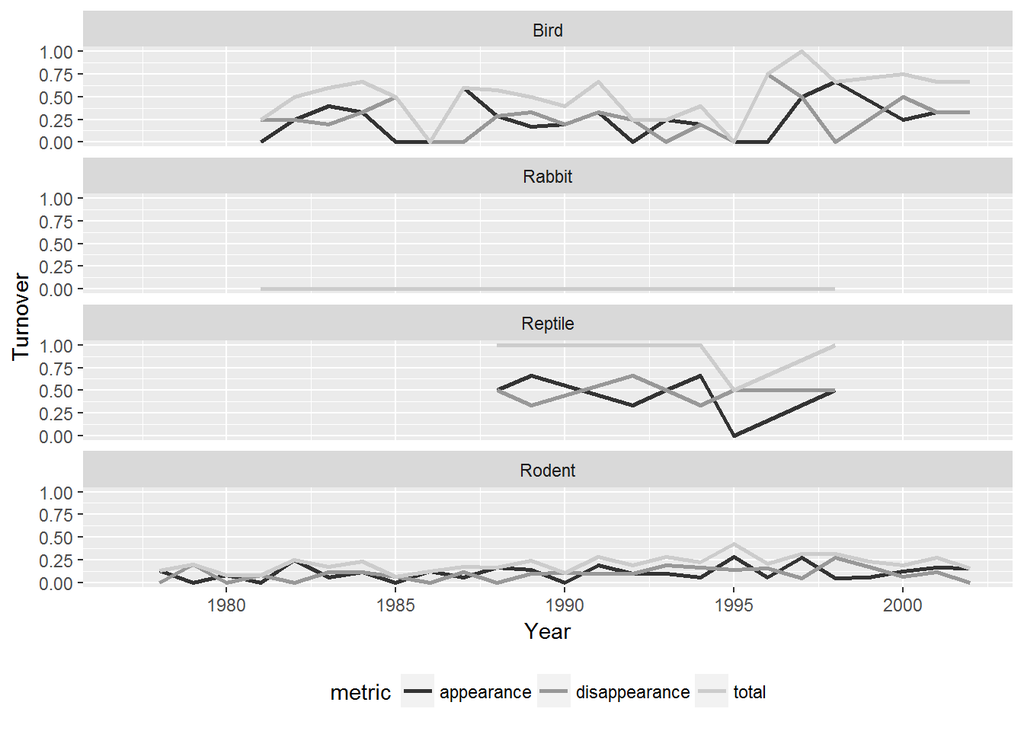

```r
portal.turnover <- gather(portal.turnover, key = metric, value = turnover,
                          total, appearance, disappearance)

turn.plot <- ggplot(
  portal.turnover, aes(x=year, y=turnover, color=metric)) +
  geom_line(size = 1, show.legend = T) +
  facet_wrap(~taxa, ncol = 1)+
  xlim(1977,2002)+
  xlab("Year")+
  ylab("Turnover")+
  theme(legend.position="bottom")+
  scale_color_grey()
plot(turn.plot)
```

*Question 5*:

1. How does temporal turnover relate to spatial turnover?
2. Which taxonomic group appears to be the most variable? Which group appears to be the least variable?

> *Answer 5a*: The temporal turnover that we detect could be the result of spatial turnover occuring across the sampling area. In other words, the effects of spatial and temporal turnover are not entirely independent.

> *Answer 5b*: Birds appear to be the most variable in their turnover rates, but reptiles have the highest sustained total turnover rates of all the taxa (though there appears to be limited data). Rabbits have a sustained total turnover rate of 0 and rodents maintain a low, but variable, turnover rate across the years sampled.

### Mean Rank Shift

In the code chunk below, do the following:

1. Choose two plot_types or two plot_ids and compare the mean rank shift (MRS) between them.
2. Plot MRS for each through time.

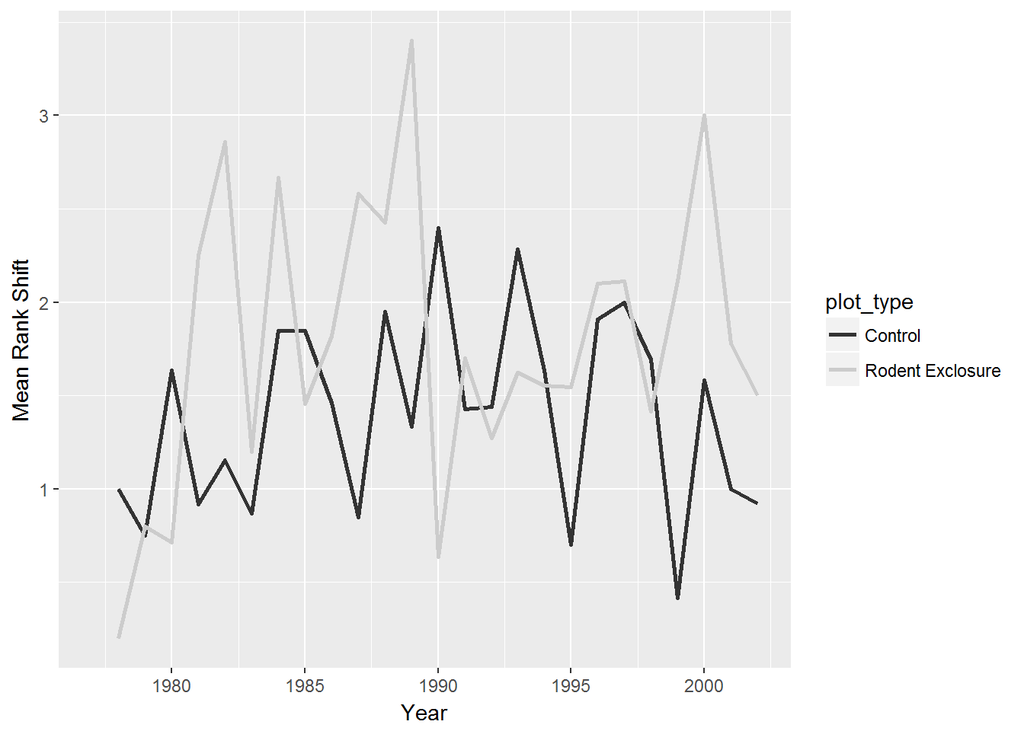

```r
portal.species.abunds <- group_by(portal, year, plot_type) %>% count(taxon)

portal.abunds.cont.rodent <- filter(portal.species.abunds,
                                    plot_type == "Control" | plot_type == "Rodent Exclosure")

portal.rankshift <- rank_shift(
  df = as.data.frame(portal.abunds.cont.rodent),
  time.var = "year",
  species.var = "taxon",
  abundance.var = "n",
  replicate.var = "plot_type"
)


portal.rankshift$year <- as.numeric(substr(portal.rankshift$year_pair, 6, 9))

rankshift.plot <- ggplot(portal.rankshift, aes(x = year, y = MRS, color = plot_type))+
  geom_line(size = 1) +
  xlim(1977, 2002)+
  xlab("Year")+
  ylab("Mean Rank Shift")+
  scale_color_grey()

plot(rankshift.plot)
```

```r
group_by(portal.rankshift, plot_type) %>%
  summarise(
    mean = mean(MRS),
    cv = sd(MRS/mean)
  )
```

```
## # A tibble: 2 × 3
##          plot_type     mean        cv
##              <chr>    <dbl>     <dbl>
## 1          Control 1.400675 0.3759483
## 2 Rodent Exclosure 1.788980 0.4361809
```

*Question 6*:

1. What does a change in the rank shift tell you about the community?
2. Interpret the analysis and figure you just made.

> *Answer 6a*: A change in rank shift would suggest that there have been changes in species-specfic rank abundances. That certain species have become rarer and others more common. *Answer 6b*: The mean rank shift for the `Rodent Exclosure` treatment is in most years higher than the `Control` treatment suggesting that the rodent exclosures contribute to changes in species composition over time due to shifts in species abundance. Mean rank shift is also more variable for the rodent exclosures as can be seen by the elevated value for the relative standard deviation (or CV). The rodent exclosures may be contributing to more drastic shifts in species abundance and turnover.

### Rate Change Interval

In the R code chunk below, do the following:

1. Calculate the rate change interval using the Hellinger distance.
2. Plot the results.

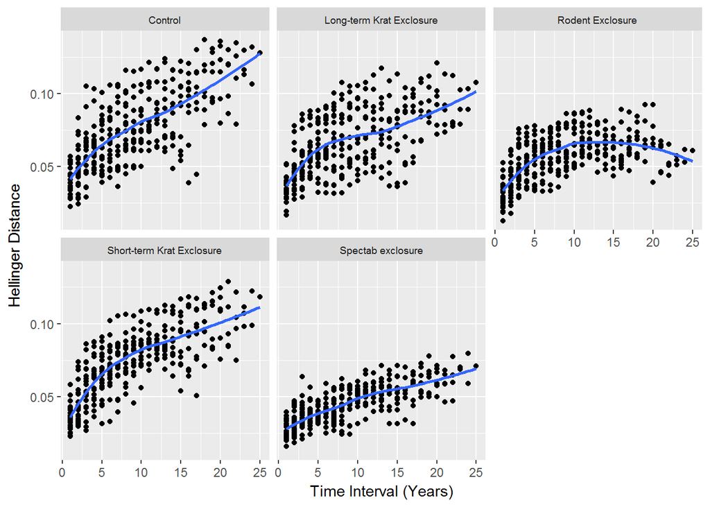

```r
portal.species.abunds$tot.abund <- rep(sum(portal.species.abunds$n),
                                       length(portal.species.abunds$n))


portal.hellinger.transf <- portal.species.abunds %>%
  mutate(hellinger.transf = sqrt(n / tot.abund))

portal.change.int <- rate_change_interval(portal.hellinger.transf,
                                          time.var = "year",
                                          species.var = "taxon",
                                          abundance.var = "hellinger.transf",
                                          replicate.var = "plot_type")

rate.plot <- ggplot(portal.change.int, aes(interval, distance)) +
  geom_point()+
  facet_wrap(~plot_type)+
  theme(strip.text.x = element_text(size = 7))+
  stat_smooth(method = "loess", se = F, size = 1)+
  ylab("Hellinger Distance")+
  xlab("Time Interval (Years)")
rate.plot
```

*Question 7*:

1. What does it mean to calculate a distance metric across varying time intervals?
2. Interpret the overall results. Develop a hypothesis based on the different responses of each treatment.

> *Answer 7a*: It means that we are quantifying if and how quickly communities diverge over time. *Answer 7b*: First, the `control` treatment has the quickest rate of community divergence based on the “slope” of the loess line. This relationship is also very linear. The treatments `Long-term Krat Exposure`, `Short-term Krat Exposure`, and `Spectab exclosure` maintain the linear trend yet have overall reduced rates of divergence. The slowest rate of divergence was for the `Spectab exclosure`. The `rodent exclosure` rate change interval plot has a peculiar parabolic shape. I hypothesize that the exclosures, by reducing overall diversity in the plots, make for a more stable community over time. Specifically, given that the `Spectab exclosure` treatment reduced the rate of divergence the most, I would hypothesize that Banner-tailed kangaroo rats have a strong influence on community divergence over time. Why this is the case, I cannot say.

## 7) STABILITY

In the R code chunk below, do the following:

1. Using total abundance as your focal variable, calculate stability (i.e., 1/CV) and synchrony for each plot type.
2. Test for a biodiversity-stability relationship by regressing community stability on mean richness.
3. Test for a biodiversity-stability relationship by regressing community stability on mean inverse Simpson’s diversity.

```r
portal.stab <- community_stability(df = as.data.frame(portal.species.abunds),
                                   time.var="year",
                                   abundance.var = "n",
                                   replicate.var = "plot_type")
pander(portal.stab)
```

| plot_type | stability |
| --- | --- |
| Control | 3.044 |
| Long-term Krat Exclosure | 1.865 |
| Rodent Exclosure | 1.864 |
| Short-term Krat Exclosure | 2.462 |
| Spectab exclosure | 2.911 |

```r
time.by.species <- group_by(portal, year, plot_id,
                            plot_type) %>% count(taxon) %>% spread(key = taxon, value = n, fill = 0)

richness <- as.data.frame(rowSums(time.by.species[,-c(1:3)] > 0 ))


rich.all_R <- data.frame(time.by.species[,1:3,], richness)
names(rich.all_R)[4] <- "richness"


###SNYCHRONY
portal.loreau <- synchrony(df = as.data.frame(portal.species.abunds),
                           time.var = "year",
                           species.var = "taxon",
                           abundance.var = "n",
                           replicate.var = "plot_type",
                           metric = "Loreau")

names(portal.loreau)[2] <- "loreau"

portal.gross <- synchrony(df = as.data.frame(portal.species.abunds),
                          time.var = "year",
                          species.var = "taxon",
                          abundance.var = "n",
                          replicate.var = "plot_type",
                          metric = "Gross")
names(portal.gross)[2] <- "gross"

pander(full_join(portal.loreau, portal.gross))
```

| plot_type | loreau | gross |
| --- | --- | --- |
| Control | 0.1869 | 0.1263 |
| Long-term Krat Exclosure | 0.1578 | 0.07418 |
| Rodent Exclosure | 0.187 | 0.1423 |
| Short-term Krat Exclosure | 0.08773 | 0.001546 |
| Spectab exclosure | 0.1542 | 0.1393 |

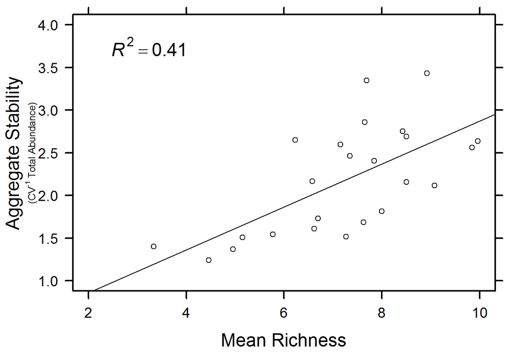

```r
####FOR RICHNESS

portal.mean.rich.plot <- rich.all_R %>%
  group_by(plot_id) %>%
  summarise(mean.rich = mean(richness))

portal.plot.abunds <- as.data.frame(
  group_by(portal, year, plot_id) %>% count(taxon))
portal.stab.plot <- community_stability(df = portal.plot.abunds,
                                        time.var = "year",
                                        abundance.var = "n",
                                        replicate.var = "plot_id")

portal.div.stab <- portal.mean.rich.plot %>%
  inner_join(portal.stab.plot)
par(mar = c(5,5,1,1))
plot(portal.div.stab$stability ~ portal.div.stab$mean.rich,
      xlab = "", ylab = "", yaxt = "n", xaxt = "n",
     xlim = c(2,10), ylim = c(1,4))

axis(side = 1, cex.axis = 1.2, lwd.ticks = 2, las = 1)
axis(side = 2, cex.axis = 1.2, lwd.ticks = 2, las = 1)
axis(side = 3, lwd.ticks = 2, las = 1, labels = F)
axis(side = 4, lwd.ticks = 2, las = 1, labels = F)
box(lwd = 2)
mtext("Mean Richness", side = 1, line = 3, cex = 1.5)
mtext("Aggregate Stability", side = 2, line = 3.5, cex = 1.5)
mtext(expression(paste("(CV"^"-1"," Total Abundance)")),
      side = 2, line = 2.25, cex = .8)

div.stab.lm <- lm(portal.div.stab$stability ~ portal.div.stab$mean.rich)
abline(div.stab.lm)
r2 <- bquote(italic(R)^2 == .(format(
  summary(div.stab.lm)$adj.r.square, digits = 3)))

text(3.25, 3.75, cex = 1.5, labels = r2)
```

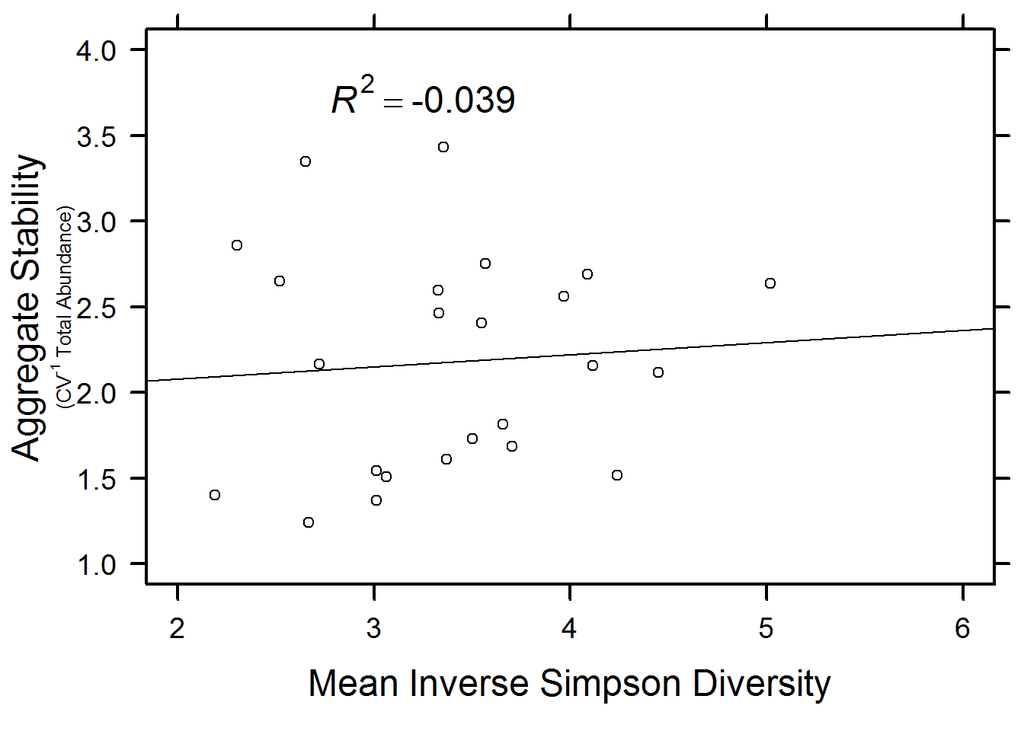

```r
#####FOR INV SIMP

portal.mean.rich.plot <- rich.all %>%
  group_by(plot_id) %>%
  summarise(mean.rich = mean(inverse_S))

portal.plot.abunds <- as.data.frame(
  group_by(portal, year, plot_id) %>% count(taxon))
portal.stab.plot <- community_stability(df = portal.plot.abunds,
                                        time.var = "year",
                                        abundance.var = "n",
                                        replicate.var = "plot_id")

portal.div.stab <- portal.mean.rich.plot %>%
  inner_join(portal.stab.plot)
par(mar = c(5,5,1,1))
plot(portal.div.stab$stability ~ portal.div.stab$mean.rich,
      xlab = "", ylab = "", yaxt = "n", xaxt = "n",
     xlim = c(2,6), ylim = c(1,4))

axis(side = 1, cex.axis = 1.2, lwd.ticks = 2, las = 1)
axis(side = 2, cex.axis = 1.2, lwd.ticks = 2, las = 1)
axis(side = 3, lwd.ticks = 2, las = 1, labels = F)
axis(side = 4, lwd.ticks = 2, las = 1, labels = F)
box(lwd = 2)
mtext("Mean Inverse Simpson Diversity", side = 1, line = 3, cex = 1.5)
mtext("Aggregate Stability", side = 2, line = 3.5, cex = 1.5)
mtext(expression(paste("(CV"^"-1"," Total Abundance)")),
      side = 2, line = 2.25, cex = .8)

div.stab.lm <- lm(portal.div.stab$stability ~ portal.div.stab$mean.rich)
abline(div.stab.lm)
r2 <- bquote(italic(R)^2 == .(format(
  summary(div.stab.lm)$adj.r.square, digits = 3)))

text(3.25, 3.75, cex = 1.5, labels = r2)
```

*Question 8*:

1. Which plot type has the highest stability in total abundance? How is stability of total abundance measured with the function you learned? How does this measure of stability relate to the coefficient of variation?
2. In your own words, describe the concept of synchrony
3. Interpret the results from the biodiversity-stability relationships you analyzed.

> *Answer 8a*: The `Control` plot type has the highest stability. Stability is measured as the inverse of the coefficient of variation (CV) where CV = (stdev/mean). The function we learned takes the species abundance matrix, calculates the mean and standard deviation for abundance across sites of the same type, calculates the CV, and then takes the inverse. *Answer 8b*: Synchony measures if and how species densities (for the same environment or treatment) are correlated over time. If they are strongly correlated, this may indicate that the species as whole will respond to changes in the environment together and that they may be susceptible to environmental disturbances. *Answer 8c*: Regressing stability on mean richness verified the prediction of biodiversity-stability theory. Increased richness was associated with increased stability (R2 = 0.41). Conversely, when regressing stability on inverse of Simpson’s diversity, we do not see this relationship. Although the plot looks like it has a slightly positive slope, R2 = -.039. Simpsons diversity takes into account richness AND evenness, so using this metric may provide a better indication of the true biodiversity-stability relationship.

## SYNTHESIS

Compare and contrast the core concepts from temporal and spatial diversity (e.g., autocorrelation, scale, variability, etc.). Identify a few of the major challenges associated with studying biodiversity through time and across space.

> *Answer*: *Autocorrelation in time and space.* Spatial autocorrelation refers to the degree to which sites that are close to one another in space have similar trait values. Similarly, temporal autocorrelation is the degree to which a variable at one time point is correlated with the same variable at a later (or earlier) time point. *Scale:* Having the appropriate scale in spatial studies is critical. We want to have a large enough extent to capture the the dynamics of the entire range but we also want a small snough grain to resolve significant patterns. While not explicitly mentioned, I feel the same could be said for temporal studies of diversity. We want a large extent (over many years) and a small grain (sampling every month as opposed to every year) in order to capture the effects of seasonality and other imporant attributes that may affect diversity across time. *Variability:* Variation in diversity across space can broadly be grouped into three categories: environment, space, and environment+space. In the Beta-Diversity assignment, we learned how to partition this variation to understand the relative contributions of each to the observed patterns of diversity. Studying diversity temporally allows us to quantify how diversity varies through time. We can visualize this variation, formally test for effects of other variables while accounting for non-independence through time, build models that attempt to capture temporal variation or seasonal patterns, study variation in species turnover through time, look at species divergence by site through time, as well as measure stability through direct quantification of variation through time (CV, synchrony, variance ratios, biodiversity-stability relationship). A major challenge in studying spatial diversity is understanding the relative contributions of geographic distance and environmental divergence on species distributions. Often times these two factors are confounded. In other words, disentangling isolation-by-environment and isolation-by-distance to arrive at a formal conclusion on which is driving patterns of observed diversity is rather tough even if we can partition the variation. Two major challenges in studying temporal patterns of diversity is 1) accounting for non-independence of observations in longitudinal studies and 2) building acurate forecasting models to describe patterns of diversity into the future.